# 第一章：RStudio与R Markdown入门

章节作者：刘贇喆 | 华东师范大学 社会发展学院

更新时间：2026-03-08

章节概述

本章作为数据科学实战的逻辑起点，目标是搭建一套可稳定复用的科学计算工作流。你将完成 R 与 RStudio 的环境部署与核心工具集 `tidyverse` 的配置，并通过引入 R Project 的项目机制与相对路径管理，尽量规避跨平台协作中常见的路径失效与文件组织混乱问题，从而建立更稳健的工程基础。

在此基础上，本章将重点解析 R Markdown 的可复现写作范式。掌握这种“代码与叙述共生”的报告结构，是实现研究过程透明与结果可追溯的关键，也将直接支撑你完成本课程后续所有作业与项目报告。

# **本章学习内容**

## **学习导航**

**本章学习内容**

欢迎开始 **第 1 章** 的学习。请点击 **下方导航卡** 进入相应小节：

环境配置

RStudio 与 Project

工具管理

包的安装与调用

文档架构

R Markdown 工作流

语法规范

Markdown 语言基础

写作规范

代码与引用格式

章节练习

复现与挑战

💡 **提示**：学习完一个小节后，请再次点击 **屏幕右下角的**章节主页**按钮**回到本导航页

**© 华东师范大学 社会发展学院 人口研究所** | [**DAWN 研究组**](https://dawn-ecnu.github.io) | yzliu@soci.ecnu.edu.cn

课程负责人：刘贇喆 本章作者：刘贇喆

最后更新：2026年03月08日 构建环境：R version 4.5.2 (2025-10-31)

[CC BY-NC-SA 4.0](https://creativecommons.org/licenses/by-nc-sa/4.0/deed.zh) 回到顶部

## **1.0 RStudio 基础**

### **1.0 RStudio 与 R Project**

#### **1.1 初始界面预览**

初次安装后启动时，RStudio 主界面默认呈“三栏式”布局（见 Figure 1.1）。为了更好地理解数据分析的工作流，我们需要掌握以下三个核心区域的功能定义：

- **左侧：控制台** (Console) **[Figure 1.1 红框]**

  这是 R 语言的**执行内核**与**交互中心**。在此处输入的指令会被系统**立即读取并运行** (Evaluate)，随即反馈运算结果。你可以将其视为与 R 引擎进行直接对话的“指令终端”。
- **右上：环境面板** (Environment) **[Figure 1.1 蓝框]**

  这是 R 的**对象管理器** (Object Manager)。它以清单形式实时展示当前内存中已载入的所有数据对象，包括数据集 (Data Frames)、变量 (Variables) 及自定义函数 (Functions)。它是我们监视数据状态、确保数据成功载入的核心窗口。
- **右下：多功能面板** (Files/Plots/Packages) **[Figure 1.1 绿框]**

  这是 R 的**资源与输出管理区**。该区域集成了文件路径导航 (Files)、可视化图表预览 (Plots) 以及扩展包管理 (Packages) 等多种辅助功能，是连接本地文件系统与分析结果的桥梁。

[figure not shown]

Figure 1.1 第一次打开RStuido的界面（默认界面）

#### **1.2 第四区域：源代码编辑器**

Figure 1.1 的初始界面尚未呈现数据科学工作流中的核心环节——**脚本管理**。**控制台** (Console) 虽支持即时交互与反馈，但其操作记录具有**易失性**。为确保研究过程的**持久化存储**与研究结果的**可复现性**，需启用第四大核心区域：**源代码编辑器** (Source Editor)。

#### **1.2.1 创建 R Script 文档**

通过点击 RStudio 界面左上角的 **New File** 图标，并在下拉菜单中选择 **R Script**，即可建立新的脚本文件。

新建文档后，界面将转换为标准的四面板工作区 （见 Figure 1.2），新增区域说明如下：

- **左上：源代码编辑器** (Source) **[Figure 1.2 黄框]**

  源代码编辑器专用于编写与管理分析代码。与控制台单次输入、即时执行的交互模式不同，在此区域编写的脚本 (Script) 为结构化的指令集合。该模块支持代码的存储、编辑及批量运行，是建立标准化且可复现的数据分析流程的基础。

[figure not shown]

Figure 1.2 成功创建新文件后的四栏标准工作台

#### **类比理解：把 RStudio 当作一间厨房**

用一个生活类比快速记住四个面板的分工：

- **Source（编辑器）**：写“菜谱” (保存流程，便于复现)
- **Console（控制台）**：下锅执行 (运行/测试代码)
- **Environment（环境）**：看“食材清单” (当前对象/数据)
- **Plots（绘图区）**：看“出菜效果” (图表输出)

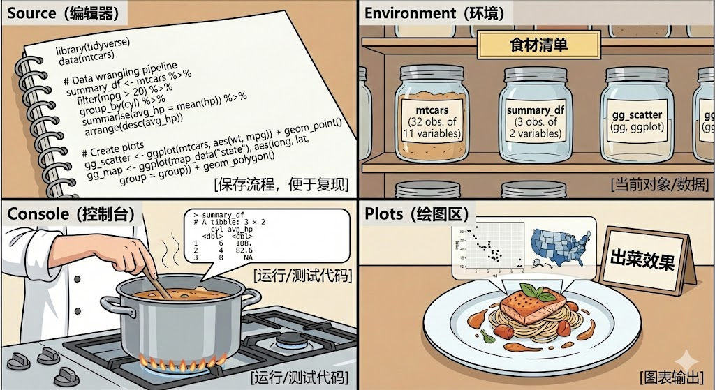

#### **1.2.2 编写第一段脚本 / R 代码**

在新建的默认名为 `Untitled1` 的空白脚本中输入以下代码。

代码各行末尾均附有**注释** (Comments)。添加注释属于规范的编程实践，旨在提升代码的**可读性**，明确各项指令的具体功能与逻辑意图，从而便于日后的代码审查与协同维护。

```r
# 1. 字符输出
print("Hello World")  # 将字符串输出至控制台 (Console)

# 2. 基础算术运算
1 + 1                 # 加法运算
4 - 1                 # 减法运算
2 * 2                 # 乘法运算
5 / 2                 # 除法运算

# 3. 对象赋值与操作
x <- 10               # 将数值 10 赋值给对象 x
x^2                   # 计算 x 的平方
y <- 20               # 将数值 20 赋值给对象 y
x / y                 # 计算对象 x 除以 y 的商

# 4. 向量创建与基础函数计算
z <- c(x, y, 30)      # 使用 c() 函数创建包含多个数值的向量 z
mean(z)               # 计算向量 z 的算术平均值
```

#### **注释符 (`#`) 与代码文档化**

在 R 语言中，**井号 (`#`)** 用以标识注释：  
自 `#` **起至该行末尾的文本**，均不会被解释器解析或执行。

- **语法机制**：  
  代码运行时，解释器会自动略过 `#` 及其后续内容，该部分文本纯粹作为代码解释，不参与任何底层运算。
- **编程规范**：  
  注释的核心功能在于提升代码的可读性与可维护性。符合学术规范的脚本不仅需确保语法正确，还应具备完善的文档属性。建议利用注释详细记录参数设定的依据与分析步骤的理论支撑 （研究逻辑），而非仅仅复述代码的执行动作。

**实践建议**： 在代码编写阶段进行详尽的逻辑记录，是保障长期研究项目可复现性的关键环节。对处理步骤与参数依据的严谨注释，可显著降低后期代码审查、重构及协同开发的成本。

#### **1.2.3 运行代码 (Run)**

**方式一：逐行执行（推荐操作 ）**

在标准的数据分析工作流中，通常采用“逐行编写、逐行执行”的模式，以便实时验证输出结果的准确性与逻辑的合理性。

- **光标定位**：  
  无需高亮选中整行代码，仅需将光标置于**目标行的任意位置**。
- **执行操作**：
  - **鼠标点击**：  
    点击脚本面板右上角的 **Run** 按钮。
  - **快捷键**：
    - Windows 操作系统： Ctrl + Enter
    - macOS 操作系统： Cmd ⌘ + Enter

> **运行机制**：单行指令执行完毕后，光标将自动下移至次行，从而支持代码的连续执行与测试。

**方式二：批量执行**

当需要一次性运行**多行**代码块或完整脚本时：

1. **选定代码**：  
   使用鼠标拖拽以**高亮选中**目标代码段。
2. **执行操作**：  
   点击 **Run** 按钮，或使用上述相同的快捷键指令。

#### **1.3 项目化工作流：引入 R Project**

重要

完成开发环境配置后，需立即构建标准化的项目文件管理体系。

数据科学项目通常涉及多种文件类型，如**原始数据**(`.../data/`)、**代码脚本**(`.../script/`)、**输出图表**(`.../outputs/`)及**中间结果**(`.../temp/`)等。

[figure not shown]

Figure 1.3 项目文件分级示意图

若缺乏严谨的目录层级组织，常会导致文件寻址困难、版本控制混乱，以及因**文件路径** (File path) 配置错误而引发的代码执行中断。为此，RStudio 引入了基于 **R Project** (R 项目) 的标准化项目管理工作流。

#### **1.3.1 核心机制：工作目录的锚定**

**R Project** 的核心机制在于为特定的分析任务构建一个**自包含**的工作环境 (Self-contained)。

创建 Project 后，RStudio 将自动把项目根目录设定为**当前工作目录** (Current working directory)。该目录即作为文件寻址的**锚点**：后续所有文件的读取与存储操作均以此作为基准起点，进而确立稳定且具备高度复用性的项目架构。

- **传统模式的局限**：  
  高度依赖绝对路径 (Absolute path)（如 `C:/Users/Name/Documents/Analysis/data.csv`）。当项目文件发生物理迁移、目录结构重组或跨设备操作时，极易导致路径失效与代码运行中断。
- **R Project 的优势**：  
  支持采用相对路径 (Relative path)（如 `data/survey.csv`）。在项目文件夹内部结构保持不变的前提下，即使项目整体发生迁移，代码路径依然有效。此机制大幅提升了数据分析的**可移植性**与**可复现性**。

#### **不要在代码中使用绝对路径**

初学者最常见的错误之一，是在代码里写 **绝对路径** （Absolute path）。例如读取 `survey.csv`：

**❌ 错误示例（绝对路径）**

```r
my_data <- read.csv("C:/Users/张三/Desktop/survey.csv")
```

（含义：让 R 去某台电脑的 C 盘、某个用户目录下逐层查找文件）

**为什么不推荐？**  
这种写法强依赖本机目录结构 （Local dependency）：同一段代码往往只能在当前电脑上运行。一旦更换电脑/账号，或把代码发给同学、助教与导师，路径就可能不存在，进而导致读取失败并报错。

**✅ 推荐做法（相对路径）**  
在 **R Project** 下，使用**相对路径** （Relative path）：只需写明文件在项目中的相对位置即可，例如 `data/survey.csv`。

```r
my_data <- read.csv("data/survey.csv")
```

（含义：从当前项目根目录出发，到 data/ 文件夹中读取数据）  
一句话总结：只要文件仍在项目文件夹内，无论项目被移动到哪里，相对路径通常都能保持有效 （Portability & Reproducibility）。

#### **1.3.2 创建新的 R Project**

本节将详细阐述遵循标准规范的 R Project 创建流程。

Step 1 **启动向导**：点击 RStudio 界面右上角的 立方体图标 (Project)，并在下拉菜单中选择 **New Project…**。

Step 2 **选择类型**：在弹出的向导窗口 (Wizard) 中 （见 Figure 1.4 - 1.5），依次进行以下操作：

[figure not shown]

Figure 1.4 创建新R Project步骤：1

[figure not shown]

Figure 1.5 创建新R Project步骤：2

Step 3 **设置详情**：此步骤用于确定项目的物理存储路径，需遵循系统命名规范。

- **Directory name** (目录名)：  
  输入 `Chapter_1`。
- **Create project as subdirectory of**：  
  点击右侧 **Browse** 选择用于存放该项目的主文件夹路径。
- 完成上述设置后，点击 **Create Project**。RStudio 将自动重载工作环境，界面右上角将显示当前项目名称 `Chapter_1`。

[figure not shown]

Figure 1.6. 创建新R Project步骤：3

#### ⚠️ **核心命名规范**

为确保代码运行的长期稳定性与跨平台兼容性，文件及文件夹的命名需严格遵循以下三项核心原则：

- **避免使用中文字符**：  
  R 语言环境对非 ASCII 字符（如中文）路径的支持**存在局限**，极易在文件读取与写入过程中引发编码错误或乱码问题。
- **禁止使用空格**：  
  文件系统中包含空格的路径易导致解释器解析异常。建议使用下划线 (`_`) 或连字符 (`-`) 作为替代词缀分隔符（例如 `final_project`）。
- **规避特殊符号**：  
  严禁使用系统保留字符或特殊符号（如 `/`, `:`, `*`, `?`, `<`, `>`, `|` 等），以防干扰底层系统的路径解析机制。

#### **1.3.3 核心原则：项目文件的标准启动流程**

重要

项目创建完成后，指定的系统目录下将自动生成以 `.Rproj` 为扩展名的配置文件。为确保工作环境的正确加载与相对路径的生效，需遵循以下标准化**启动流程**：

#### 💡 **项目环境的正确加载机制**

每次开启分析任务时，请务必通过以下两种规范途径之一激活项目环境：

- **途径一：基于文件系统的直接启动** 在操作系统的文件资源管理器中，**直接双击运行** `.Rproj` 配置文件。

  > **⚠️ 避免错误操作**：切勿直接双击打开 `.R` (R Script) 或 `.Rmd` (R Markdown) 等具体的脚本文件。此操作仅会加载单一文本文件，无法激活关联的 R Project 环境，进而导致工作目录未被正确锚定以及后续的文件读取报错。
- **途径二：基于 RStudio 界面内的项目切换** 若已预先启动 RStudio 主程序，可通过点击界面右上角的项目管理下拉菜单 (Project Menu)，选择 **Open Project…** 或从最近项目列表中点击目标名称，以切换至对应的 `.Rproj` 工作环境。

**© 华东师范大学 社会发展学院 人口研究所** | [**DAWN 研究组**](https://dawn-ecnu.github.io) | yzliu@soci.ecnu.edu.cn

课程负责人：刘贇喆 本章作者：刘贇喆

最后更新：2026年03月08日 构建环境：R version 4.5.2 (2025-10-31)

[CC BY-NC-SA 4.0](https://creativecommons.org/licenses/by-nc-sa/4.0/deed.zh) 回到顶部

## **2.0 R 包的管理**

### **2.0 R 包的管理**

载入新建的 `Chapter1` 项目环境后，RStudio 界面**通常**默认呈现三面板布局。其原因在于：当前工作区尚未载入或创建任何脚本文件，致使源代码编辑器 (Source 面板) 处于未激活状态。

在系统性论述 R 包机制前，需预先在当前项目中**创建并存储代码脚本文件**，以此作为后续指令执行与逻辑记录的基础载体。

#### **2.1 脚本文件的构建与存储**

基于 1.2 节详述的操作规范，在当前项目中构建新脚本文件的标准流程如下：

Step 1 **初始化脚本**：  
点击 RStudio 工具栏左上角的 图标，并在下拉菜单中选择 **R Script**。执行此操作后，界面左上方的源代码编辑器将被激活并展开为标准的**四面板布局**。

Step 2 **持久化存储**：  
新建脚本后，需立即执行保存操作以防数据丢失。点击源代码编辑器上方的 (Save) 图标，将该文件命名为 `lab_01.R`。系统将默认把该脚本写入并留存于当前 R Project 的工作目录之中。

#### **2.2 核心概念：Base R 与扩展包**

重要

**R 包** (Package) 本质上为特定功能模块的标准化集合，通常封装了自定义函数、帮助文档及示例数据集。R 语言在数据处理、统计建模与可视化等领域的核心优势，高度依赖于此类包的协同运作。

为深入解析 R 语言的运行机制，需界定以下两个架构层级：

- **基础 R** (Base R)：即 R 的原生系统层。在初始安装阶段即默认配置的一系列核心包 (Base and recommended packages)，提供最底层的通用计算与基础统计能力。
- **扩展包** (Extension packages)：由全球开发者社区维护并托管于 CRAN 等中央存储库的外部功能模块，用于针对性地拓展专业分析能力。

在概念模型上，此架构类似于“智能手机生态” (见图 2.1)：

[figure not shown]

Figure 2.1. R 与 R Packages/Libraries 的关系比喻

**基础 R** (Base R) 相当于操作系统的预装核心组件 (Out-of-the-box)。它具备基础运算能力，但在应对高度复杂或专业化的分析任务时存在局限性。

而 **R 包** (Packages) 则相当于**按需安装**的第三方应用程序 (Applications)。例如，通过引入 `ggplot2` 包可构建现代化的数据可视化工作流，引入 `dplyr` 包则能显著提升数据清洗与操作的执行效率。借助此类模块化扩展机制，R 语言的分析能力得以根据具体的研究需求进行无缝拓展。

#### **这些“APP”从何而来？**

- **CRAN** （可理解为“官方仓库”）  
  全称 *The Comprehensive R Archive Network*。多数常用包发布在 CRAN，上架需要符合 CRAN 的提交规范，并通过一系列自动化检查与跨平台构建测试 （Quality checks）。  
  通常使用 `install.packages()` 安装，版本相对稳定，适合课程与常规科研复现。
- **GitHub（及其他开发者平台）**  
  一些包会先以“开发版/研究前沿工具”的形式托管在 GitHub，未必同步发布到 CRAN。此时可用 `devtools` （或更轻量的 `remotes`） 直接从仓库安装：

  ```r
  install.packages("devtools")  # 仅需安装一次
  devtools::install_github("houseofcommonslibrary/statxplorer")
  ```

  **示例用途：下载公开数据** `statxplorer` 是一个用于访问英国 DWP Stat-Xplore Open Data API 的 R 包，可把 API 查询结果返回为便于分析的数据结构（需先注册并获取 API key）（API key）。

#### **2.3 运行机制：安装与加载**

重要

明确了 **R 包** (Package) 在 R 生态系统中的定位后，掌握其管理机制是后续分析的基础。该管理流程的核心操作主要分为两个步骤：**安装** (Install) 与 **加载** (Load)。

这两个操作在执行频率与代码语法上存在显著差异。为直观区分，可参考“灯泡与开关”的概念模型 (见 Figure 2.2)：

- **安装包 `install.packages("包名")`**：相当于“安装灯泡”
  - **操作逻辑**：将目标包从中央存储库下载并部署至本地计算机的 **包库** (Library) 中。
  - **执行频率**：单次配置；通常只需操作一次，除非面临设备更换、软件重装或环境重置等情况。
  - **版本维护**：若需获取已安装包的最新版本，可执行 `update.packages()` 函数。
- **加载包 `library(包名)`**：相当于“打开开关”
  - **操作逻辑**：在当前的 **工作会话** (Session) 中激活该包，使其内置函数处于可用状态。
  - **执行频率**：高频操作；通常每次启动新的工作环境时均需重新执行。处于安装状态但未被加载的包，其内部函数无法被直接调用。

[figure not shown]

Figure 2.2. R 与 R 安装和加载包 的关系比喻

#### **2.3.1 语法差异：引号的使用规则**

重要

在代码编写过程中，**安装** (Install) 与 **加载** (Load) 存在一个易被混淆的语法特征：**引号的有无**。

#### **参数传递机制：引号的作用**

对比以下两条常用指令：

- **安装阶段：需使用引号** `install.packages("tidyverse")`  
  (安装时需将包名作为字符串传递给存储库进行检索与下载，因此需加引号)
- **加载阶段：通常省略引号** `library(tidyverse)`  
  (加载时直接按名称调用当前工作环境中已安装的模块，通常无需将其作为字符串处理)

(补充说明：`library("tidyverse")` 的写法同样有效，但在实际编码中更倾向于采用省略引号的常规形式)

#### **2.3.2 基于图形界面的包管理机制**

可选操作 (菜单栏工具安装)

除命令行操作外，RStudio 提供了基于 **图形用户界面** (Graphical user interface, GUI) 的程序包管理方案，便于直观地执行相关维护操作。

在右下角工作区选择 `Packages` 标签，界面将呈现以下核心功能：

- **已安装模块列表**：展示包名、版本信息及当前的加载状态 (以复选框勾选状态表示)。
- 安装：用于检索并部署新包。
- 更新：用于升级已安装包的版本。

> 提示：基于图形界面的包管理操作，其底层机制仍是在控制台调用相应的 R 语言指令，仅在交互层面进行了可视化封装。

#### **2.4 核心扩展包的配置与加载**

基于前述的包管理机制，本节将在新建的 `lab_01.R` 脚本中进行基础数据科学工具包 `tidyverse` 的配置与加载。

#### **2.4.1 核心工具集简介：tidyverse 元程序包**

在 R 语言生态系统中，`tidyverse` 通常被定义为**元程序包** (Meta-package)。它并非提供单一功能的独立模块，而是整合了一系列设计哲学一致、底层数据结构兼容且能高效协同工作的包集合。

在概念上，其功能定位类似于数据科学领域的“多功能集成工具” (强调高度集成与通用性)。`tidyverse` 依托于**整洁数据** (Tidy data) 的核心理论，功能覆盖数据导入、清洗、结构转换与可视化等标准分析流程，为常规数据科学任务提供了一套高度标准化的工具链。

此类集成化架构的主要优势体现在以下两个维度：

1. **部署效率**：  
   免去了逐一配置离散功能的繁琐步骤；对于常规的基础分析工作流，通常仅需部署 `tidyverse` 即可基本满足需求。
2. **语法一致性**：  
   各子包间的函数命名规范与数据操作逻辑高度统一，支持在“数据清洗—结构转换—统计绘图”等不同环节间实现顺畅的数据流转，从而有效降低长期学习与跨团队协作的成本。

[figure not shown]

Figure 2.3. R 与 R Packages: tidyverse

知识拓展：Tidyverse 生态宇宙

`tidyverse` 是一套基于共享设计哲学、语法规范及通用数据结构构建的 **R 包集合**。其并非单一功能的扩展模块，而是系统性整合了现代数据科学工作流的分析生态。安装部署完成后，系统将默认包含以下核心组件 (点击卡片可访问官方文档)：

ggplot2 可视化

dplyr 数据操控

tidyr 数据规整

readr 数据读取

stringr 文本处理

未列出的包：如**lubridate** (时间日期 ), **tibble** (现代数据框), **purrr** (函数式编程) 等。

[Tidyverse 官网](https://www.tidyverse.org/)

#### 2.4.2 代码编写与执行

请回到左上角的 **Source**，在 `lab_01.R` 文件中输入以下代码：

```r
# --- Step 1: 安装 (只需运行一次) ---
# 注意：包名必须加引号
install.packages("tidyverse")

# --- Step 2: 加载 (每次重启 RStudio 后需重新运行) ---
# 注意：包名无需引号
library(tidyverse)
```

操作回顾：逐行执行 (Run)

基于 1.2.3 节 的操作规范，将光标定位至代码首行，并通过以下快捷键发送执行指令：

- **Windows**: Ctrl + Enter
- **macOS**: Cmd ⌘ + Enter

**运行机制**：单行指令执行完毕后，光标将自动下移至次行，以支持代码的连续解析与运行。

若指令解析正常 (成功下载、配置并调用 library(tidyverse))，控制台 (Console) 将反馈如下环境加载信息。该加载详情通常仅在当前工作会话初次调用该模块时输出；后续重复加载时默认不再显示：

```r
library(tidyverse)
```

[output not shown]

#### **tidyverse 加载日志解析与逻辑说明**

执行 `library(tidyverse)` 指令后，控制台 (Console) 会反馈详细的加载日志。该信息核心反馈了以下三个维度的环境状态：**激活的模块构成、各组件版本信息、以及函数命名冲突提示**。

##### **1) 环境挂载信息** `Attaching core tidyverse packages ...`

- **挂载** (Attaching)：指将 tidyverse 的核心功能模块导入当前 **工作会话** (Session)。挂载完成后，相应模块内置的函数即可在当前环境中直接调用。
- **版本标识**：例如 `tidyverse 2.0.0` 代表该元程序包的整体版本。需明确的是，tidyverse 作为 **包集合** (Meta-package)，其内部各子组件均拥有独立的版本演进。

##### **2) 核心组件清单与功能概览**

日志列出了随 tidyverse 自动加载的一组 **核心扩展包** (Core packages)，格式通常为 `✔ 包名 版本号`。

常用组件及其主要分析功能概览如下：

- `dplyr`：数据操纵与逻辑变换 (如筛选、汇总、连接等)
- `ggplot2`：基于图形语法的数据可视化
- `readr`：结构化文本数据 (如 CSV, TSV) 的读取
- `tidyr`：数据重塑与规整 (如长宽表转换)
- `tibble`：现代化、易读性更高的轻量级数据框
- `stringr`：字符串处理与正则表达式工具
- `forcats`：因子型 (Factor) 变量的处理
- `lubridate`：日期与时间数据的解析
- `purrr`：泛函编程与迭代工具

> **逻辑说明**：在初阶分析阶段，无需记忆各包的全量函数。重点在于理解 tidyverse 构建了一套高度协同的分析工具链，能够覆盖数据处理的全生命周期。

##### **3) 函数命名冲突提示** `Conflicts ...`

该部分旨在提示：**不同程序包中存在同名函数**，R 需根据优先级确定默认执行的函数。

例如当控制台显示：`dplyr::filter() masks stats::filter()`

- **遮蔽** (Masks)：表示直接调用 `filter()` 时，R 将优先执行 **dplyr** 的版本，而 **stats** 包中的同名函数在默认情况下被覆盖。
- **命名空间运算符** (Namespace operator)：即 `::` 符号，用于显式指定特定包内的函数。
  - `dplyr::filter()`：明确调用 **dplyr** 包中的函数。
  - `stats::filter()`：明确调用 **stats** 包中的函数。

**处理函数冲突的规范做法：**

- **显式声明命名空间（推荐）**：使用 `包名::函数名()` 形式书写代码，可有效**消除歧义**，提升代码在跨环境操作时的稳定性与可复现性。
- **查询实时冲突**：通过调用 `tidyverse_conflicts()` 函数，可实时获取当前环境下的命名冲突清单。

##### **4) 进阶管理建议** (可选了解)

若需在开发流程中强制规避潜在的同名函数调用风险，可引入 `conflicted` 包。该模块会将冲突情况转化为报错提示，要求开发者显式选择所需的函数版本。在入门阶段，仅需知晓其功能定位即可。

**© 华东师范大学 社会发展学院 人口研究所** | [**DAWN 研究组**](https://dawn-ecnu.github.io) | yzliu@soci.ecnu.edu.cn

课程负责人：刘贇喆 本章作者：刘贇喆

最后更新：2026年03月08日 构建环境：R version 4.5.2 (2025-10-31)

[CC BY-NC-SA 4.0](https://creativecommons.org/licenses/by-nc-sa/4.0/deed.zh) 回到顶部

## **3.0 文档架构**

### **3.0 R Markdown**

> **“R Markdown provides a unified authoring framework for data science, combining your code, its results, and your prose commentary.”** > — *Hadley Wickham & Garrett Grolemund*

在传统的数据分析流程中，**“数据解析”** (运行代码) 与 **“成果产出”** (撰写报告) 通常处于解构状态。

这种分离模式会导致**“结果静态化”**的局限：一旦原始数据或分析逻辑发生变更，研究者必须重复执行 “重运行脚本 → 导出图表 → 人工更新报告” 的繁琐流程。此类操作不仅增加了维护成本，且在版本控制与图表替换过程中极易引入人为错误 (如数据不一致或内容遗漏)。

**R Markdown** (.Rmd) 引入了高度集成的写作范式：它将 代码 (Code)、运算结果 (Results) 与 叙述性文本 (Narrative) 封装于同一份可执行文档内，从而将分析过程与报告呈现整合为统一的**可复现工作流** (Reproducible workflow)。

当需更新分析内容时，仅需执行一次 **Knit** 操作 (编译/渲染)：系统将按逻辑顺序自动重新解析代码块，并实时生成最新的统计表、可视化图表及结论说明，确保分析结果与报告内容的同步更新。

[figure not shown]

Figure 3.1. 传统工作流 (左) 与 R Markdown 工作流 (右) 的对比

#### **3.0.1 R Markdown 的主要应用场景**

R Markdown 能够有效覆盖数据分析中三类核心的沟通与记录场景：

**1. 决策支持维度**  
决策层通常更关注结论与建议而非底层技术细节。R Markdown 支持在输出文档中隐藏代码块，仅呈现关键图表与统计分析结果，从而生成聚焦于业务洞察的专业报告。

**2. 团队协作维度**  
协作流程通常涉及对分析逻辑与结果来源的复核。R Markdown 将计算代码、运算输出与逻辑解释整合于同一文档，提升了分析过程的透明度，并增强了研究的**可复现性** (Reproducibility)。

**3. 知识管理与长期维护**  
数据分析包含大量中间决策与假设验证过程。R Markdown 作为动态研究日志，可完整记录分析思路、参数选择与关键逻辑解释，有效降低了后续回溯与维护的认知成本。

#### **3.0.2 技术原理与渲染工作流**

掌握 R Markdown 的基本运行机制有助于构建稳定的分析流。该系统主要由以下两个层级构成：

**1. 核心基础：Markdown** (Plain text)  
R Markdown 的写作基础为 **Markdown**，这是一种强调易读性与轻量化的标记语言。

- **纯文本属性**：不依赖特定的闭源排版系统，兼容各类文本编辑器，且便于执行版本管理。
- **结构化语法**：利用简洁符号定义文档结构与样式 (如使用 `#` 标识标题，使用 `**` 标识加粗)，使撰写过程聚焦于内容逻辑而非排版细节。

**2. 功能扩展：R Markdown** (Integrated code blocks)  
在 Markdown 基础上，RStudio 引入了 **knitr** (Rendering engine)。该架构的核心能力在于：在正文中嵌入可执行的代码块，并将运算产出的表格、图形或数值自动整合至最终文档。

执行 “Knit” (渲染) 操作时，系统将启动自动化处理流 (Pipeline)：

1. **knitr**：解析并执行代码块，生成运算结果与相应的可视化图表。
2. **Pandoc**：对文本与计算输出进行格式转换与排版处理。
3. **Output**：生成最终格式的目标文档 (如 HTML、Word 或 PDF)。

#### **3.1 环境准备与新建**

#### **3.1.1 扩展模块配置**

RStudio 通常预装了基础支持。为确保环境功能的完整性，需在初始阶段执行以下指令以配置核心编译组件：

```r
# 安装 R Markdown 核心功能包
install.packages("rmarkdown")

# 安装渲染引擎包
install.packages("knitr")
```

#### **3.1.2 构建 R Markdown 文档**

R Markdown 文档的创建过程遵循标准化的交互流程，主要涵盖文件初始化与基础元数据 (Metadata) 配置两个阶段。

**Step 1 文件创建**

点击 RStudio 顶部工具栏左上角的 图标，并从下拉菜单中选择 R Markdown… 选项。

**Step 2 初始设置**

在弹出的配置窗口中，需定义文档的核心元数据 (见 Figure 3.2)：

- **Title**：文档标题。
- **Author**：署名作者。
- **Default Output Format**：初始阶段建议设定为 **HTML** 格式。

确认配置后 (点击 OK)，系统将自动生成包含预设示例内容的 `.Rmd` 模板文件，支持在此基础上直接执行内容编辑与功能扩展。

[figure not shown]

Figure 3.2 创建新 R Markdown

#### **3.1.3 默认文档结构解析**

成功初始化文档后，编辑器将自动加载一段**模板文本** (Template)。该模板的逻辑架构可解构为以下四个核心组成部分：

**1. 元数据区域 (YAML Header)**

- **位置**：起始于文档顶端，由两组连续的短横线 `---` 封装。
- **功能定义**：该区域作为文档的全局**元数据** (Metadata) 配置区，用于规范文档的标题、作者信息以及预设的输出格式。示例配置如下：

```
---
title: "First Practice"     # 文档的主标题 (默认是一级标题)
author: "YunzheLiu"         # 作者署名
date: '`r Sys.Date()`'      # 日期 (此处使用的 R 代码运行后自动获取当前日期)
output: html_document       # 输出格式 (HTML网页)
---
```

#### **核心概念：YAML 配置语言**

YAML (YAML Ain’t Markup Language) 是一种轻量化的配置管理语言。在 R Markdown 文档中，该区域负责**元数据** (Metadata) 的定义，涵盖标题、作者、日期及输出格式等核心参数。后续亦可用于扩展目录 (Table of Contents)、视觉主题及代码高亮样式等进阶设定。

**配置过程中建议遵循以下排版规范：**

1. **冒号后的空格要求**：在键名与键值之间需插入一个空格。
   - 规范形式：`title: My Report`
   - 非规范形式：`title:My Report`
2. **缩进方式的选择**：YAML 语法对层级逻辑具有高度敏感性。建议仅使用空格 (通常为 2 个字符) 进行对齐，避免使用 Tab 键，以防导致渲染解析异常或配置失效。

**2. 全局设置区 (Global Setup Chunk)**

- **位置**：通常位于 YAML 区域下方的首个代码块。该区域由三反引号封装，并在花括号内声明编程语言及配置参数。
- **功能定义**：该区域作为文档的全局默认配置项，用于统一调控后续各代码块的执行行为与显示模式。例如，可通过设定 `knitr::opts_chunk$set(echo = TRUE)` 来规范全文代码块的可见性。

````
```{r setup, include=FALSE}
knitr::opts_chunk$set(echo = TRUE)
```
````

- `setup` (代码块标签)：该代码块的唯一标识名称。在复杂的文档中，为代码块分配唯一的标识通常有助于后期的维护与错误定位。
- `include = FALSE` (参数设定)：使代码块在渲染过程中处于“静默执行”状态。这意味着代码将被运行，但其源码及其产出的任何结果都不会在最终报告中显示。
- `echo = TRUE` (参数设定)：设定后续所有代码块的默认显示逻辑。在此参数下，报告通常会同步展示代码源码与其执行结果，以增强分析过程的透明度。

**3. 文本写作区 (Markdown Text)**

- **位置**：文档中未被代码块 (Chunk) 包裹的任意区域。
- **功能定义**：这是文档的主体部分，支持使用标准的 Markdown 语法撰写研究背景、方法论解析以及最终的数据结论。

```markdown
## R Markdown
This is an R Markdown document. Markdown is ...
```

以及

```markdown
## Including Plots
You can also embed plots, for example:
```

以及

```markdown
Note that the `echo = FALSE` parameter was added to the code chunk to prevent printing of the R code that generated the plot.
```

- `##`：二级标题 （Heading level 2）  
  例：`## 研究背景`
- 正文：直接输入即可 （与 Word 类似）
- 超链接有两种常用写法：
  1. **自动链接（只显示网址）**  
     模板：`<网址>`  
     例：`<http://www.baidu.com>`
  2. **命名链接（显示文字，更推荐）**  
     模板：`[显示文字](网址)`  
     例：`[百度](http://www.baidu.com)`
- 行内代码 （Inline code）：用一对反引号包起来  
  模板：`` `代码` ``  
  例：这样写：`` `code` ``

**4. 示例文本中的 代码运行区 (R Code Chunks)**

- **位置**：由三个反引号 `` ```{r} `` 开头，并由三个反引号 `` ``` `` 结尾的区域。
- **定义**：这是用于编写并执行 R 代码的独立区域。在此区域内的文本会被 RStudio 识别为代码命令而非普通文字。

````
```{r cars}
summary(cars)
```
````

以及

````
```{r pressure, echo=FALSE}
plot(pressure)
```
````

- `{r cars}`：
  - `r`：声明该代码块使用 **R 语言** （engine）。
  - `cars`：该代码块的**标签** （label），用于标识与定位这个代码块（便于排错与引用）。
  - `summary(...)`：用于输出数据的描述性统计 （descriptive statistics），例如最小值、四分位数、中位数、均值、最大值等。
  - `cars`：R 自带的示例数据集 （内置数据集），包含车辆速度与刹车距离的观测值。
- `{r pressure, echo=FALSE}`：
  - `pressure`：该代码块的**标签** （label）。
  - `echo=FALSE`：表示**不显示代码，只显示输出** （结果/图形）。
  - `plot(...)`：基础绘图函数，用于生成图形输出 （plot）。
  - `pressure`：R 自带的示例数据集 （内置数据集），记录温度与汞蒸气压之间的关系。

#### **运行机制：一键渲染 (Knit)**

点击编辑器上方的 **Knit** (编织/渲染) 按钮后，系统将按文档的逻辑顺序依次解析并执行各**代码块** (Code Chunks)。

在此过程中，后台会同步处理文档内的计算逻辑与绘图指令。例如，执行 `summary(cars)` 以获取描述性统计结果，或通过 `plot(pressure)` 生成可视化图表。运算产出的数值、表格及图形将依据预设的逻辑结构，自动整合至最终生成的输出文档中，从而确保分析记录与展示结果的高度同步。

**© 华东师范大学 社会发展学院 人口研究所** | [**DAWN 研究组**](https://dawn-ecnu.github.io) | yzliu@soci.ecnu.edu.cn

课程负责人：刘贇喆 本章作者：刘贇喆

最后更新：2026年03月08日 构建环境：R version 4.5.2 (2025-10-31)

[CC BY-NC-SA 4.0](https://creativecommons.org/licenses/by-nc-sa/4.0/deed.zh) 回到顶部

## **4.0 R Markdown 语法**

### **4.0 Markdown 语法速查**

Markdown 的核心设计哲学在于内容驱动的文档构建：其通过标准化的标记符号实现文档的结构化排版，从而有效降低了复杂的排版样式调整对撰写过程的干扰。

以下为常用的基础语法概览。

#### **4.1 标题与层级 (Headers)**

在 Markdown 语法体系中，通常采用井号 `#` 作为**标题** (Headers) 的标识。井号的数量对应文档的逻辑层级，且各层级的视觉权重通常随深度增加而依次递减。

| **你的输入** | **预览效果** |
| --- | --- |
| `# 一级标题` | 一级标题 |
| `## 二级标题` | 二级标题 |
| `### 三级标题` | 三级标题 |
| `...` | … |

#### **关键规则：空格不能少！**

井号 `#` 与标题文字之间**必须保留一个空格**：

- ✅ **正确**：`## 标题` （会被识别为标题）
- ❌ **错误**：`##标题` （通常会被当作普通文本）

补充：Markdown 标题最多支持 6 级（`######`）。

#### **4.2 文本样式与格式化 (Text Formatting)**

在 Markdown 语法中，文本样式的实现主要依赖于特定标识符对目标字符的“封装”。以下为数据分析报告中常用的格式化指令：

| **语法** | **你的输入** | **预览效果** |
| --- | --- | --- |
| **加粗** | `**重点内容**` | **重点内容** |
| *斜体* | `*辅助说明*` | *辅助说明* |
| 删除线 | `~~过时信息~~` | 过时信息 |
| 行内代码 | `` `mean()` `` | `mean()` |
| 上标/下标 | `X^2^` / `H~2~O` | X<sup>2</sup> / H<sub>2</sub>O |
| 换行（软换行） | 行末两空格 + 回车 | （同段内换行） |
| 分隔线 | `---` | （水平分隔线） |

#### **文本格式化应用逻辑与规范**

- **加粗** (Bold)：用于强调核心结论或关键性规则。建议仅针对局部关键术语进行标注，避免全文大范围应用以保持视觉重点的有效性。
- **斜体** (Italics)：通常用于标注补充性说明、专业术语或轻量级的语义强调。
- **删除线** (Strikethrough)：用于保留历史分析记录或已弃用的结论，以此向读者明确该内容已不在当前版本中采纳 (在学术性报告中应用频率相对较低)。
- **行内代码** (Inline Code)：适用于标注函数名称、参数配置、数据对象或变量。例如 `filter()`、`echo = TRUE` 或 `my_data`。
- **上标与下标** (Superscript and Subscript)：主要应用于数学表达式、度量单位或化学式。例如 `km^2^` 或 `H~2~O`。

#### **常见误区：行内代码 ≠ 高亮强调**

行内代码 `` `...` `` 的主要作用是“把它当作代码/符号”来呈现 （monospace），适合函数与参数。  
如果你只是想强调一句话，更推荐用 **加粗** 或 *斜体*。

#### **4.3 列表**

列表常见两类：**无序列表** （圆点） 与 **有序列表** （编号）。  
写作建议：无序列表适合“并列要点”，有序列表适合“步骤流程”。

#### **A. 无序列表**

无序列表可用 `-`、`*` 或 `+` 开头（建议全篇统一使用一种符号，最常用的是 `-`）。

| **语法** | **你的输入** | **预览效果** |
| --- | --- | --- |
| **基础列表** | `- 苹果` `- 香蕉` | • 苹果 • 香蕉 |
| **层级嵌套** (子列表) | `- 水果` `- 苹果` `- 香蕉` | • 水果 ◦ 苹果 ◦ 香蕉 |
| **同一条内换行** (同一个 bullet) | `- 研究对象：伦敦 OAs` `（数据来源：2021 Census）` | • 研究对象：伦敦 OAs （数据来源：2021 Census） |

#### **关键规则：空格与缩进**

1. **符号后必须有空格**：`-` 后要加空格 （写成 `-Item` 通常不会被识别为列表）
2. **缩进产生层级**：子列表建议使用 **4 个空格** （或 Tab），并保持对齐一致

#### **B. 有序列表**

有序列表使用 `1.`、`2.` 这类“数字 + 点”开头。

| **语法** | **你的输入** | **预览效果** |
| --- | --- | --- |
| **基础排序** | `1. 打开 RStudio` `2. 新建文件` `3. 保存` | 1. 打开 RStudio 2. 新建文件 3. 保存 |
| **懒人编号** (自动纠正) | `1. 第一步` `1. 第二步` `1. 第三步` | 1. 第一步 2. 第二步 3. 第三步 |
| **步骤中含子要点** | `1. 读取数据` `- 检查缺失值` `- 统一变量类型` | 1. 读取数据 • 检查缺失值 • 统一变量类型 |

#### **4.4 链接与图片引用 (Links and Images)**

在 Markdown 语法体系中，**外部链接**与**图像资源**的构造逻辑具有高度的相似性。其核心差异主要体现在标识符的微调上：

- **外部链接**：采用 `[描述文本](URL 路径)` 的语法结构。
- **图像引用**：采用 `![替代文本](图像路径或 URL)` 的语法结构。

两者的关键区别在于：**图片引用需在引导符首位添加感叹号 `!`**。该符号的作用是向渲染引擎声明当前内容为图像可视化呈现，而非可跳转的文本链接。

**功能定义**

**语法结构**

**渲染示意**

**超链接插入**

`[R 官网](https://www.r-project.org)`

[R 官网](https://www.r-project.org)

**图像资源引入**

`![R Logo](https://www.r-project.org/Rlogo.png)`

> **运行逻辑**：**替代文本** (Alt text) 在图像因网络或路径异常无法加载时，将作为占位文本显示；同时，该字段通常也有助于辅助技术 (如屏幕阅读器) 对图像内容进行解析。

#### **应用建议：叙述性链接的优势**

相较于直接展示长 URL，采用 `[描述文本](URL 路径)` 的形式通常更具可读性：读者可直观理解链接指向的内容，且文档布局更为整洁。

图像引用亦遵循类似逻辑：建议在 `![替代文本](...)` 字段中清晰阐述图像的核心内涵。这不仅有助于图像检索，也为**辅助技术** (如屏幕阅读器) 提供了必要的上下文信息，确保了文档的无障碍访问 (Accessibility)。

#### **典型异常识别**

1. **引导符遗漏**：若忽略首位的感叹号 `!`，Markdown 渲染引擎将按照普通文本链接进行解析，导致图像无法在最终文档中可视化。
2. **路径引用策略**：在圆括号 `(...)` 中定义的资源路径通常分为以下两类：
   - **网络链接**：以 `http` 或 `https` 协议开头。
   - **本地资源**：建议采用**相对路径** (Relative path)，例如 `images/my_plot.png`。

> **运行逻辑**：使用相对路径有助于提升项目的可迁移性。当整个项目文件夹移动至其他设备或目录时，只要资源与脚本的相对位置保持不变，文档通常仍可正常渲染。

#### **进阶技巧：基于代码块的图像控制**

重要

Markdown 原生的图像语法在属性控制 (如精确尺寸调整、对齐方式、自动编号与题注) 方面存在一定局限性。若需实现更精细的排版控制，推荐通过 **R 代码块** 调用 `knitr::include_graphics()` 函数：

````
```{r, echo=FALSE, out.width="50%",fig.align='center', fig.cap="Figure X.图片标题"}
knitr::include_graphics("/我的图片/图片x.png")
```
````

**常用参数说明**：

- `echo=FALSE`：不显示代码，只显示图片输出 （适合正式报告）
- `knitr::include_graphics()`：插入图片文件 （支持 png/jpg/pdf 等）
- `out.width="50%"`：输出宽度为页面宽度的 50% （也可写 `"300px"`）
- `out.height="200px"`：设置输出高度 （可与 out.width 配合使用）
- `fig.align='center'`：图像对齐方式 （‘left’ / ‘center’ / ‘right’）
- `fig.cap="..."`：图题 （caption），用于解释图像含义并支持自动编号（取决于输出格式设置）
- `fig.alt="..."`：替代文本 （无障碍阅读与检索更友好）

#### **4.5 引用与分割线**

- **引用**：用于摘录一段话、强调重点或表示“注脚”。
- **分割线**：用于在视觉上把文档切分成上下两部分。

| **语法** | **你的输入** | **预览效果** |
| --- | --- | --- |
| **区块引用** (大于号) | `> 这是一个重要的定义` `> 也是重点` | 这是一个重要的定义 也是重点 |
| **分割线** (三个短横线) | `---` | ──────────────────── |

举个例子：

我们输入这个：

```
> "I thoroughly disapprove of duels. If a man should challenge me,
  I would take him kindly and forgivingly by the hand and lead him
  to a quiet place and kill him."
>
> --- Mark Twain
```

Knit之后的效果：

> “I thoroughly disapprove of duels. If a man should challenge me, I would take him kindly and forgivingly by the hand and lead him to a quiet place and kill him.”

> — Mark Twain

#### **使用小技巧**

1. **引用嵌套**：你甚至可以使用 `>>` 来创造“引用中的引用”（双层缩进）。
2. **分割线避坑**：输入 `---` 时，**上下最好各空一行**。如果 `---` 紧贴在文字下方，Markdown 可能会把它误认为是“二级标题”的标记。

#### **4.6 数学公式 (LaTeX Math)**

R Markdown 完美支持 LaTeX 数学公式。公式主要分为 **行内** (Inline) 和 **独立** (Display) 两种。

| **语法** | **你的输入** | **预览效果** |
| --- | --- | --- |
| **行内公式** (一个 `$` 符号) | `$E=mc^2$ 是质能方程` | $E=mc^2$ 是质能方程 |
| **上标与下标** (常用的 `^` 和 `_`) | `X^2^` (上标) `H~2~O` (下标) `$X_i$` (数学下标) | X<sup>2</sup> H<sub>2</sub>O $X_i$ |
| **希腊字母** (斜杠+读音) | `$\alpha$` `$\beta$` `$\pi$` | $\alpha$ $\beta$ $\pi$ |

#### **进阶：如何写复杂的大公式？**

如果你想写那种**独占一行、居中显示**的大公式，请使用 **两个 Dollar 符** `$$` 包裹：

```
$$
\sum_{i=1}^{n} (x_i - \bar{x})^2
\qquad \text{与} \qquad
X = \begin{bmatrix}
1 & x_{1}\\
1 & x_{2}\\
1 & x_{3}
\end{bmatrix}
$$
```

Knit之后的效果：

$$\sum_{i=1}^{n} (x_i - \bar{x})^2
\qquad \text{与} \qquad
X = \begin{bmatrix}
1 & x_{1}\\
1 & x_{2}\\
1 & x_{3}
\end{bmatrix}$$

#### **4.7 代码：行内代码与代码块**

R Markdown 的核心优势之一，是可以在同一份文档中同时写 **叙述文本** 与 **可执行代码**。这里有两个最重要、也最容易混淆的概念：**行内代码**（Inline Code） 与 **代码块** （Code Chunks）。

##### **4.7.1 行内代码：把结果“嵌入一句话里”**

行内代码用于把一个计算结果插入到文本中，语法是：

- 用一对反引号包裹，并在开头写 `r`：

```markdown
`r 表达式`
```

| **用途** | **你的输入** | **预览效果** |
| --- | --- | --- |
| 自动插入日期 | `` 今天日期：`r Sys.Date()` `` | 今天日期：2026-03-08 |
| 插入计算结果 | `` 2 + 3 = `r 2 + 3` `` | 2 + 3 = 5 |
| 插入对象值 | `` 样本量 n = `r nrow(mtcars)` `` | 样本量 n = 32 |

#### **关键规则：行内代码适合“短小表达式”**

- ✅ 适合：日期、简单运算、一个对象的值（如 `nrow()`、`mean()`）
- ❌ 不适合：多行代码、复杂数据处理、绘图等（这些请用“代码块”）

##### **4.7.2 代码块：运行一段完整 R 代码**

重要

代码块用于执行一段相对完整的代码（多行也可以），并把输出（表格/文字/图）呈现在报告中。基本结构如下：

````
```{r}
x <- 1:5 # 将一个数值向量（从 1 到 5 的整数序列）赋值 (‘<-’) 给变量 x
mean(x)  # 计算 x 向量中所有数值的平均值: (1 + 2 + 3 + 4 + 5) / 5
```
````

在代码块中，你可以执行任何有效的 R 代码，R Markdown 会自动捕获并显示代码的输出。以下是一些常用的参数设置，可以帮助你自定义代码块的行为：

- `eval`

`eval` 参数决定是否执行代码， 默认值是 `TRUE`，表示代码会被执行。如果将其设置为 `FALSE`，代码会被展示，但不会运行。常用于需要展示代码而不执行的情况。

````
```{r, eval=FALSE}
x <- 1:5
mean(x)
```
````

- `echo`

`echo` 参数决定是否在输出中显示代码。默认值是 `TRUE`，即显示代码。如果将其设置为 `FALSE`，代码不会显示，只会显示结果。

````
```{r, echo=FALSE}
x <- 1:5
mean(x)
```
````

- `results`

`results` 参数控制如何显示代码输出。常见的设置有：

1. `markup`：默认值，输出为格式化文本
2. `asis`：原样显示输出，不进行格式化

````
```{r,results='asis'}
cat("比较一下这组代码的区别") # cat() 是 R 里常用的“把文字输出到屏幕”的函数
```
```{r,results='markup'}
cat("比较一下这组代码的区别")
```
````

- `message` 和 `warning`

参数控制是否显示代码中的消息和警告。将它们设置为 `FALSE` 可以禁止显示消息或警告

- `fig.width` 和 `fig.height` 这两个参数用于控制图形输出的大小。你可以根据需要调整图形的宽度和高度。

````
```{r,fig.width = 6, fig.height= 4} # 可自由变换参数试验
plot(mtcars$mpg, mtcars$hp) # 以 mtcars数据中的 mpg列作为 x轴，以hp列为 y轴出散点图
```
````

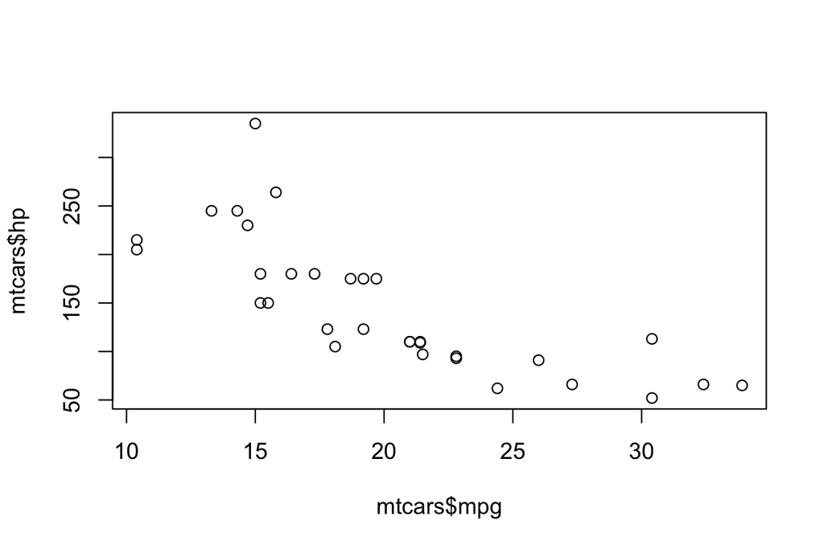

#### **4.8 表格：在 R Markdown 中展示数据**

表格是数据分析报告中最常见、也最重要的呈现方式之一：无论是**数据展示**、**描述性统计**，还是最终的**研究结果汇报**，表格都能用更清晰、可对照的方式把关键信息表达出来。

在 R Markdown 中，你既可以**手动插入表格**（适合写“概念对照表”），也可以用 R 代码**自动生成表格**（适合展示真实数据与分析结果）。

#### **方式 1：手动制表（适合概念表 / 速查表）**

不常用

当你需要呈现**“类型对照”**、**“流程清单”**、**“参数说明”**时，手动表格最直接。以下是一个 4×3 的示例：

输入：

```
|  **概念** |  **含义** |  **示例** |
|:---:|:---:|:---:|
| 数据类型 | 单个值的“类别” | `numeric`, `character` |
| 数据结构 | 数据的组织方式 | vector, data.frame |
| 索引 | 取出数据的方法 | `x[1]`, `df$y` |
| 可复现 | 结果可重复生成 | 同一份代码多次 Knit |
```

| **概念** | **含义** | **示例** |
| --- | --- | --- |
| 数据类型 | 单个值的“类别” | `numeric`, `character` |
| 数据结构 | 数据的组织方式 | vector, data.frame |
| 索引 | 取出数据的方法 | `x[1]`, `df$y` |
| 可复现 | 结果可重复生成 | 同一份代码多次 Knit |

> 提示：这种制表方式一般来说用的比较少，因为我们通常想展示已经读写的数据

#### **方式 2：用 `knitr::kable()` 自动生成表格**

常用

在数据分析中，你最常遇到的是**“把数据的一部分展示出来”**，例如：查看前几行、展示某些列、生成描述性统计表。

R Markdown 中常用 `knitr::kable()` 把数据对象直接渲染成整洁表格。

> **补充说明：`knitr::kable()` 是什么意思？**

> `knitr` 是一个扩展包（package），`kable()` 是它提供的函数。双冒号 `::` 表示“从某个包里调用函数”，即 `包名::函数名`。  
> 这样写的好处是：**不必先 `library(knitr)` 也能直接使用**，同时能清晰表明函数来源，减少“同名函数冲突”的风险。

下面用 R 自带数据集 `mtcars` 演示：我们从数据中挑选 **6 列常用变量**，展示 **前 4 行**（4 个车型），并为表格添加标题（caption）。

```r
# mtcars 是 R 自带示例数据：
# - 每一行代表一种车型（车型名称存放在“行名”里）
# - 每一列代表一个性能指标（变量）

# 选择 6 个常用变量（列）并取前 4 行（行）
# 变量含义：
#   mpg  : Miles/(US) gallon，油耗（每加仑能跑多少英里；越大越省油）
#   cyl  : cylinders，气缸数
#   hp   : gross horsepower，马力（发动机功率）
#   wt   : weight (1000 lbs)，车重（单位是“千磅”）
#   am   : transmission，变速箱类型（0 = 自动挡，1 = 手动挡）
#   gear : number of forward gears，前进档位数

tab <- mtcars[1:4, c("mpg", "cyl", "hp", "wt", "am", "gear")]

knitr::kable(
  tab,
  caption = "Table X. mtcars 数据集前 4 行（选择 6 个常用变量）",
  digits = 2  # digits=2 表示：数值列默认保留 2 位小数，便于阅读与对齐
)
```

Table X. mtcars 数据集前 4 行（选择 6 个常用变量）

|  | mpg | cyl | hp | wt | am | gear |
| --- | --- | --- | --- | --- | --- | --- |
| Mazda RX4 | 21.0 | 6 | 110 | 2.62 | 1 | 4 |
| Mazda RX4 Wag | 21.0 | 6 | 110 | 2.88 | 1 | 4 |
| Datsun 710 | 22.8 | 4 | 93 | 2.32 | 1 | 4 |
| Hornet 4 Drive | 21.4 | 6 | 110 | 3.21 | 0 | 3 |

#### **表格怎么“更像报告”？（kable 常用自定义）**

`knitr::kable()` 可以通过一些常用参数，让输出更清晰、更接近正式报告的表格风格：

- **加标题（推荐）**：`caption = "Table 1. ..."`  
  用于说明这张表展示了什么内容，便于引用与阅读。
- **控制小数位（更整齐）**：`digits = 2`  
  让数值列默认保留 2 位小数，版面更统一；如果你希望不保留小数，可改为 `digits = 0`。
- **设置列对齐方式**：`align = c("c","c","c","c","c","c")`  
  `c/l/r` 分别表示 **居中/左对齐/右对齐**；向量长度应与列数一致。
- **更强的美化（进阶，可选）**：HTML 输出时常配合 `kableExtra`  
  例如实现表格居中、条纹底色、加粗表头、调整字体大小等。  
  本章先掌握 `kable()` 的基础用法即可；美化会在后续再系统展开。

##### **4.8.1 进阶制表**

仅作展示

进阶制表技巧，目前仅作展示使用，**暂时不用学习**

#### **进阶制表：嵌入行内可视化 (Inline Plots)**

普通的表格只能展示数字，而 **“Sparklines” (微型图)** 可以展示数据的**分布趋势**。 下面的代码展示了如何结合 `dplyr` 的数据处理能力和 `kableExtra` 的绘图功能，在表格单元格中直接绘制 **直方图** 和 **箱线图**。

> **核心技巧**： 1. 先用 `list()` 将一列数据折叠进一个单元格。 2. 使用 `kbl(escape = FALSE)` 允许 HTML 渲染。 3. 使用 `column_spec` 配合 `spec_***` 函数绘图。

```r
library(dplyr)
library(kableExtra)

# 1. 数据准备
iris_summary <- iris %>%
  group_by(Species) %>%
  summarise(
    Sepal_Mean = mean(Sepal.Length),
    Sepal_Dist = list(Sepal.Width),  # 原始数据保留在这里
    Petal_Dist = list(Petal.Length), # 原始数据保留在这里
    Count = n()
  )

# 2. 绘制表格
iris_summary %>%
  mutate(
    Sepal_Dist = "",
    Petal_Dist = ""
  ) %>%

  kbl(escape = FALSE,
      col.names = c("物种", "平均萼片长", "萼片宽分布 (直方图)", "花瓣长分布 (箱线图)", "样本数"),
      align = "c") %>%

  # --- 基础美化 ---
  kable_styling(
    bootstrap_options = c("striped", "hover", "condensed"),
    full_width = FALSE,
    position = "center",
    font_size = 16
  ) %>%

  column_spec(1, bold = TRUE, color = "#003153") %>%

  # 条件格式
  column_spec(2, color = ifelse(iris_summary$Species == "setosa", "#d9534f", "#333"),
              bold = ifelse(iris_summary$Species == "setosa", TRUE, FALSE)) %>%

  # --- 嵌入直方图 ---
  column_spec(3, image = spec_hist(iris_summary$Sepal_Dist,
                                   col = "#003153",
                                   line_col = "transparent")) %>%

  # --- 嵌入箱线图 ---
  column_spec(4, image = spec_boxplot(iris_summary$Petal_Dist,
                                      col = "#003153",
                                      fill = "#e6f2ff",
                                      width = 300,
                                      height = 50)) %>%

  row_spec(0, background = "#f8f9fa", color = "#003153", bold = TRUE)
```

| 物种 | 平均萼片长 | 萼片宽分布 (直方图) | 花瓣长分布 (箱线图) | 样本数 |
| --- | --- | --- | --- | --- |
| setosa | 5.006 |  |  | 50 |
| versicolor | 5.936 |  |  | 50 |
| virginica | 6.588 |  |  | 50 |

#### **4.9 进阶资源与 AI 辅助**

重要

`R Markdown` 的功能较为丰富，无需也不必机械记忆全部语法细节。在入门阶段，更重要的能力是学会检索、定位问题与提出清晰的问题。许多实际问题都应在操作过程中逐步掌握，而不是依赖死记硬背。

当遇到不会写的格式、输出异常或代码报错时，可优先通过以下几种方式处理。

#### **1. 查阅指南与速查资料**

以下资源适合作为日常查阅的参考材料；除下列链接外，也可根据需要自行搜索其他中英文教程。

- **北京大学《R 语言教程》** 中文推荐
  - [点击访问](https://www.math.pku.edu.cn/teachers/lidf/docs/Rbook/html/_Rbook/markdown.html)
- **R Markdown 官方指南** （The Definitive Guide）
  - [点击访问](https://bookdown.org/yihui/rmarkdown/)
- **DataCamp：R Markdown Tutorial**
  - [点击访问](https://www.datacamp.com/tutorial/r-markdown-tutorial)
- **R Markdown Cheat Sheet** 速查推荐
  - [点击访问](https://posit.co/wp-content/uploads/2022/10/rmarkdown-1.pdf)

#### **2. 视频与操作型学习资源**

若更偏好边看边做的学习方式，可优先参考 **Bilibili（B站）**、**小红书** 等平台上的入门教程。这类资源通常包含完整演示流程，便于快速建立对 `R Markdown` 工作流的直观理解。

- **推荐搜索关键词**：
  - `R Markdown 基础教程`
  - `R Markdown 入门 实战`
  - `R 语言 论文排版`
  - `RStudio 新手入门`
  - `Markdown 入门`
  - `Quarto 与 R Markdown 区别`

#### **3. 如何向 AI 提问？** （Prompting Guide）

重要

在本课程的入门阶段，生成式 AI （如 ChatGPT、Gemini、Claude、Kimi 等） 可用于辅助排查报错、理解语法与改进排版。但需要注意，AI 回答的质量高度依赖提问方式。若只给出一句“代码报错了”，通常很难获得可直接执行的解决方案。

更有效的做法，是按照下面的结构组织提问信息。

#### **通用提问结构：角色 + 背景 + 需求 + 原始信息**

- **角色设定**：说明希望 AI 以何种身份回答  
  例如：R 语言助教 / 数据分析师 / R Markdown 排版助手
- **具体背景**：交代当前任务、软件环境与输出目标  
  例如：在 RStudio 中 Knit HTML；正在编写课程作业
- **核心需求**：明确希望 AI 完成什么  
  例如：定位报错原因；修改代码；解释语法；优化排版
- **原始信息**：提供足够的上下文材料  
  例如：完整代码块；报错信息全文；截图；最小可复现示例

#### **场景 A：忘记语法 / 需要编写新代码**

❌ **低效问法**：  
“我在写 R Markdown 作业，需要插入一个表格，你告诉我怎么做？”

> **问题在哪**：这类提问仍然过于笼统。AI 无法判断你需要的是 **Markdown 原生表格**，还是 **通过 R 代码生成的表格**；也不知道你希望表格呈现几行几列、使用什么表头，以及是否有居中、美化或HTML 输出等额外要求。缺少这些信息时，往往只能得到较为泛泛的回答。

✅ **高效 Prompt（更贴合真实场景）**：  
“**[角色]** 你是一名 R Markdown 排版助教。  
**[背景]** 我正在用 RStudio 编写 `.Rmd` 作业，需要在正文中插入一个**简单 Markdown 表格** （不是用 R 代码生成）。  
**[需求]** 请给我一段可直接复制的 Markdown 代码，创建一个 **3 行 4 列**的表格。  
**[细节]** 表头为：姓名、年龄、学号、成绩；表格内容可使用示例值占位。  
**[要求]** 同时告诉我：如果希望表格在 HTML 输出中更整齐 （如居中或更美观），通常有哪些可行做法？”

#### **场景 B：代码报错 / Knit 失败** （最常见）

❌ **低效问法**：  
“我 Knit 失败了，你帮我看看怎么回事。”

> **问题在哪**：这类提问通常缺少三类关键信息：  
> 1）输出格式是什么 （HTML / PDF / Word）；  
> 2）控制台中的**完整报错信息**；  
> 3）对应的**出错代码块**与相关文件路径。  
> 若缺少这些信息，AI 往往只能给出通用建议，难以定位到可执行的修复方案。

#### ✅ **高效 Prompt（可直接复制的模板）**

- **背景**：我在 RStudio 中将 `.Rmd` 文件 Knit 为 **HTML**，过程中报错。
- **报错信息** （原文粘贴）：`Error in file(file, "rt") : cannot open the connection`
- **出错位置**：错误发生在第 X 个代码块，或提示指向 `xxx.Rmd` 的第 X 行。
- **代码片段** （完整粘贴）：

````
```{r, echo=FALSE}
knitr::include_graphics("images/fig1.png")
```
````

- **文件结构**：相关文件是否真实存在？它位于哪个文件夹？代码中引用的路径是什么？  
  例如：`images/fig1.png`
- **需求**：请判断该报错更可能属于哪一类问题 （如路径错误、文件名拼写错误、工作目录不一致、权限问题等），并给出：  
  1）建议优先检查的要点；  
  2）修复后的写法，或更稳妥的替代代码。

#### **场景 C：文档美化 / 进阶功能**

❌ **低效问法**：  
“我想把 R Markdown 做得好看一点，有什么办法？”

> **问题在哪**：目标仍然过于宽泛。AI 不清楚你想优化的是主题风格、目录结构、代码展示方式，还是版式布局；也不知道你的输出格式是 HTML、PDF 还是 Word。因此，得到的回答往往只是若干泛泛建议，而缺少可直接使用的配置代码。

✅ **高效 Prompt（聚焦 YAML 配置，便于直接使用）**：  
“**[角色]** 你是 R Markdown 排版与主题配置助手。  
**[背景]** 我正在用 RStudio 编写 `.Rmd` 文件，并 Knit 输出 **HTML**，但目前页面样式较为单调。  
**[需求]** 请帮我生成一段可直接复制的 **YAML 头文件** （YAML Header） 配置，用于美化文档。  
**[具体要求]**：  
1）使用 `flatly` 主题；  
2）添加自动目录 （TOC），并让目录悬浮显示 （`toc_float`）；  
3）开启代码折叠功能 （`code_folding`）。  
**[输出要求]**：请直接给出完整 YAML 代码，并逐行解释每个参数的作用，以及常见问题 （如缩进、冒号与空格）。”

#### **老师的建议**

AI 可以作为高效的辅助工具，但判断与理解仍需要由你自己完成。为了让 AI 真正帮助学习，而不是带来新的混乱，可特别注意以下三点：

1. **避免直接复制，优先生成“可读代码”**
   - AI 输出中常包含占位符 （如 `"YOUR_FILE_PATH"`）、默认参数，或与本机环境不完全匹配的写法，直接运行时往往容易报错。
   - **建议**：提问时明确要求：**“请逐行加注释，并标明哪些位置需要替换为我自己的路径或文件名。”**
2. **补全关键信息，降低“似是而非”的风险**
   - AI 回答的质量高度依赖输入信息。描述不完整时，得到的方案可能看似合理，但实际无法复现。
   - **建议**：至少提供以下内容：输出格式 （HTML / Word / PDF）、报错原文 （优先复制文本而非截图）、相关代码块、文件路径，以及必要时的运行环境信息 （如 `sessionInfo()`）。
3. **善用同伴讨论，提高除错效率**
   - 在编程学习中，小组讨论与相互除错 （debug） 往往能够更快定位问题。
   - **建议**：遇到卡点时，可将“报错信息 + 最小可复现代码 + 目标效果”整理后与同学讨论，这通常有助于更快形成稳定且可迁移的解决经验。

**© 华东师范大学 社会发展学院 人口研究所** | [**DAWN 研究组**](https://dawn-ecnu.github.io) | yzliu@soci.ecnu.edu.cn

课程负责人：刘贇喆 本章作者：刘贇喆

最后更新：2026年03月08日 构建环境：R version 4.5.2 (2025-10-31)

[CC BY-NC-SA 4.0](https://creativecommons.org/licenses/by-nc-sa/4.0/deed.zh) 回到顶部

## **5.0 规范与文献管理**

### **5.0 代码规范与学术引用**

掌握基础语法仅是数据分析的起点，编写高质量的代码对于研究的**可复现性**与**协作效率**至关重要。数据科学项目不仅要求代码能被计算机正确执行，更强调其在同行间（以及未来的复用场景中）的可读性与可维护性。

本节将系统介绍 R 语言社区通用的**代码风格规范**，并解析如何利用 R Markdown 的**自动化参考文献管理**功能，构建符合严谨学术标准的分析报告。

#### **5.1 代码风格规范**

核心规范

遵循一致的代码风格是保证代码可读性与可维护性的基础。  
R 语言社区普遍采纳以下三项核心规范：

**1. 命名规范：蛇形命名法**

变量与函数的命名推荐使用 **蛇形命名法** (snake_case)，即字符全部小写，单词之间以下划线连接。

- ✅ **推荐**：`student_score`, `raw_data`, `fit_model`
- ❌ **避免**：`StudentScore` (驼峰式，易混淆), `student.score` (点号在 R 中有特殊含义), `s` (无明确语义的单字母)

**2. 空格规范：运算符留白**

为增强视觉清晰度，二元运算符 (如 <-, +, =, ==) 的两侧应保留空格。

- ✅ **推荐**：`x <- 1 + 2`
- ❌ **避免**：`x<-1+2` (过于紧凑，难以阅读)

**3. 长度限制：控制行宽**

单行代码建议控制在 80 个字符以内。若代码过长，应在逗号或运算符后换行，并保持适当缩进。

#### **技巧：代码自动格式化**

高效

RStudio 内置了代码样式重构功能。选中代码段后，使用以下快捷键即可自动修正空格、缩进与换行，快速实现代码规范化：

- **Windows**: Ctrl + Shift + A
- **Mac**: Cmd ⌘ + Shift + A

#### **5.2 注释规范**

重要

注释不仅是代码的附属说明，更是**分析逻辑的载体**。在学术研究与数据科学协作中，高质量的注释应聚焦于解释代码背后的**研究意图**，而非单纯复述语法功能。

- 低效注释（语法复述）：仅重复代码的字面含义，未能提供增量信息。

````
```{r}
mean(x)  # 计算 x 的平均值
```
````

- 高效注释（逻辑阐释）：清晰说明了数据处理的动机、依据或算法逻辑。

````
```{r}
# 使用平均值填补缺失数据，因为数据分布较为对称
x[is.na(x)] <- mean(x, na.rm = TRUE)
```
````

> 核心原则：代码负责呈现 “How” (技术实现)，而注释应侧重阐释 “Why” (研究逻辑)

#### **5.3 自动化参考文献管理 (Citations)**

在学术论文撰写过程中，参考文献格式的实时调整通常是一项具有挑战性的任务。R Markdown 结合 **BibTeX** 系统构建了一套自动化的引注方案，实现了文献元数据与排版样式的解耦。相较于传统文字处理软件的人工调整模式，该机制在处理大规模引证与格式切换时具备显著的工程优势。

Step 1 **配置文献元数据库 (The .bib File)**

自动化引用的核心基础是构建一个以 `.bib` 为后缀的纯文本数据库 (例如 `references.bib`)。该文件需存放于当前 R Project 的根目录下。

`.bib` 文件用于集中存储符合 BibTeX 规范的文献条目。此类结构化的元数据通常可从 Google Scholar、PubMed 等学术搜索引擎或 Zotero、Mendely 等文献管理工具中直接导出，无需人工手动录入。

*示例内容 (references.bib):*

```
@article{wickham2014,
  title={Tidy data},
  author={Wickham, Hadley},
  journal={Journal of Statistical Software},
  volume={59},
  number={10},
  year={2014}
}
```

Step 2 **文献库的全局声明**

在 R Markdown 文档顶端的 **YAML** 元数据区域，需利用 `bibliography` 字段定义文献数据库文件的关联路径。此外，若需采用特定的学术期刊引用规范，可进一步配置 `csl` (Citation Style Language) 字段，以加载相应的引文格式定义文件。

```yaml
---
title: "第 1 章：R Markdown 入门"
output: html_document
bibliography: references.bib
csl: apa.csl
---
```

- `bibliography:` 指向你的 `.bib` 文件路径（建议与 Rmd 同目录，或写相对路径）
- `csl:` 是参考文献样式文件（例如 APA、Chicago、Nature 等）
- 若暂时不需要严格期刊格式，可以先不写 `csl`，但最终论文/作业通常建议补上

#### **资源获取：CSL 样式定义文件**

- **样式来源**：通常从 **Zotero Style Repository** 或 **Citation Styles Council** 等公共存储库检索并下载符合期刊要求的引文格式 (例如 APA 7th Edition)。
- **存储策略**：下载完成后的 `.csl` 文件建议存放于 R Project 的根目录下 (即与 .Rmd 文档同级)。这种布局有利于简化路径引用逻辑，并确保项目在跨设备迁移时的稳定性。
- **格式切换机制**：若需变更引文风格 (例如从 APA 切换至 Nature 或 GB/T 7714)，仅需修改 YAML 区域中 `csl` 字段指向的目标文件名。渲染引擎将自动重新解析文献数据，并依据新样式的定义实现全局格式的重排。

Step 3 **正文引注操作 (In-text Citations)**

在文档正文部分，通过调用**引用键** (Citation Key) 实现文献的关联引证。引用键需对应 `.bib` 数据库条目中定义的唯一 ID 标识 (例如前述示例中的 `wickham2014`)。

**常用引注语法规范：**

- **括注** (Parenthetical citations)：采用 `[@wickham2014]` 格式。渲染后，引文信息通常被完整封装在括号内，如 *(Wickham, 2014)*。该方式常用于陈述事实后的文献支撑。
- **叙述性引注** (Narrative citations)：采用 `@wickham2014` 格式 (不含方括号)。此时作者姓名通常作为句子的主语或逻辑组成部分，如 *Wickham (2014) 认为…*。
- **多文献联合引用** (Multiple citations)：在方括号内利用分号分隔多个引用键，例如 `[@wickham2014; @smith2020]`。

**源码与渲染效果对比：**

[output not shown]

> **运行逻辑**：在执行 **Knit** 指令时，Pandoc 转换引擎会自动扫描正文中的所有引用键，并从关联的 `.bib` 文件中检索对应的元数据。渲染程序不仅会在引注处生成符合 CSL 规范的文本，还会在文档末尾自动汇总并生成完整的**参考文献列表** (Reference List)。

Step 4 **自动化生成参考文献列表 (Bibliography Generation)**

在文档的末尾 (或预期的参考文献显示位置) 定义一个相应的标题。通常采用如下格式：

```markdown
# 参考文献
```

在执行 **Knit** 渲染时，**渲染引擎** (Pandoc) 会自动识别正文中已调用的引用键，并将对应的条目按选定的 CSL 样式汇总成规范的参考文献列表。该列表通常会自动排列在文档末尾的标题下方。

**运行逻辑**：在默认设置下，最终生成的列表仅包含**正文中实际被引用**的文献。若 `.bib` 数据库中的某些条目未在正文中通过引用键调用，则通常不会出现在最终的参考文献列表中。

#### **5.3.2 进阶：显示未引用的文献 (Nocite)**

可选

若需在输出文档中强制展示 `.bib` 文件中的全部条目 (无论正文是否实际引用)，可在 **YAML** 区域配置 `nocite` 字段：

```yaml
---
bibliography: references.bib
nocite: '@*'  # 强制显示文献库中的所有条目
---
```

#### **5.4 常用引用写法速查**

可选 · 速查

下面是课堂最常用的几种引用控制方式（R Markdown/Pandoc 支持）：

**1) 页码 / 定位信息**（常用于书籍或报告）

```markdown
[@wickham2014, p. 12]
```

**2) 抑制作者名，只显示年份**（当作者已在句中出现时）

```markdown
Wickham 提出…… [-@wickham2014]
```

**3) 同一句中多个引用**（注意用分号分隔）

```markdown
多项研究均支持这一结论 [@wickham2014; @smith2020; @liu2023]。
```

#### **注意：引用键（key）不要乱命名**

- 建议用 **作者姓 + 年份**：如 `wickham2014`，便于记忆与检索
- 若同一作者同一年多篇：可用 `wickham2014a`, `wickham2014b` 区分

#### **5.5 文献管理工作流：Zotero × Better BibTeX（推荐）**

可选 · 推荐

如果你希望把“引文收集—清洗—导出”做到可持续维护，建议使用：

- **Zotero**：管理文献、PDF、笔记、标签
- **Better BibTeX 插件**：自动导出 `.bib`，并保持引用键稳定

一个典型工作流：

1. 在 Zotero 中建立你的课程/论文文献库（可按章节建立 Collection）
2. 安装 Better BibTeX 插件
3. 设置“自动导出（Auto-export）”到项目目录：`references.bib`
4. 在 Rmd 中引用：`bibliography: references.bib`

这样你的 `.bib` 会随着 Zotero 的更新自动同步，避免“复制粘贴 bib 反复改错”。

#### **5.6 常见错误与排错（Troubleshooting）**

可选 · 排错

#### **如果引用不显示 / 参考文献不生成，先检查这四点**

**1) YAML 是否正确声明了 bibliography**  
- `bibliography: references.bib` 路径是否写对（大小写、相对路径）

**2) 引用键（key）是否存在且一致**  
- `.bib` 里是 `@article{wickham2014, ...}`  
- 正文必须写 `[@wickham2014]`，完全一致（含大小写）

**3) 是否真的“引用过”**  
- 若正文没有任何 `[@...]`，参考文献列表不会生成内容

**4) 是否存在非法字符**  
- `.bib` 里的 key 建议只用字母数字与下划线  
- 避免中文、空格、特殊符号

**© 华东师范大学 社会发展学院 人口研究所** | [**DAWN 研究组**](https://dawn-ecnu.github.io) | yzliu@soci.ecnu.edu.cn

课程负责人：刘贇喆 本章作者：刘贇喆

最后更新：2026年03月08日 构建环境：R version 4.5.2 (2025-10-31)

[CC BY-NC-SA 4.0](https://creativecommons.org/licenses/by-nc-sa/4.0/deed.zh) 回到顶部

## **6.0 本章练习**

### **6.0 动手实战**

实战目标

本节实战旨在通过具体任务的拆解，强化以下核心技能在真实数据分析场景中的综合应用：

- **文档架构配置 (Document Structuring)**：从初始化环境开始构建完整的 R Markdown 结构，涵盖 **YAML 元数据**、**正文叙述**与**代码块**的逻辑分层。
- **基础语法应用 (Markdown Syntax)**：涵盖多级标题、文本加粗、列表排版、超链接、图像引用及分割线等排版要素的熟练调用。
- **代码块交互与逻辑调控 (Code Chunk Management)**：执行基础 R 运算指令，并解析关键代码块参数 (如 `eval` 与 `echo`) 对最终报告呈现结果的影响。
- **工程化项目管理 (Project Management)**：在 **R Project** 框架下科学组织文件资源，并利用相对路径 (Relative Path) 实现静态资源 (如本地图片) 的稳定引用与跨平台复现。

#### **6.1 基础任务：复现“学习计划书”**

> 这是一个“**照着做**”的练习。你需要**复制结构**、**复现排版**、**跑通代码**。

> 重点不是写得多漂亮，而是把流程跑通、把概念用起来。

##### **6.1.2 标准化操作流程 (Operational Workflow)**

建议遵循以下工程化流程以确保文档的稳定渲染：

Step 1 **项目环境构建 (Project Initialisation)**：  
通过 RStudio 菜单栏执行 `File -> New Project`，创建一个名为 `Exercise_Lab1` 的新 **R Project**。

Step 2 **文档初始化 (Document Creation)**：  
在项目环境下执行 `File -> New File -> R Markdown`，并将初始标题设定为 **“My Study Plan”**。文档通常保存为 `My_Study_Plan.Rmd`。

Step 3 **静态资源配置 (Resource Anchoring)**：  
- **本地路径模式**：建议在项目根目录下新建 `img/` 文件夹，并将图像资源存放于此，例如 `img/campus.png`。  
- **网络资源模式**：获取合法且稳定的图像 URL。

Step 4 **模板套用与参数替换 (Template Implementation)**：  
将下方的标准模板导入 `.Rmd` 编辑器，并将标记为 `【需替换】` 的占位符更新为具体的分析内容。

> **建议**：在编辑过程中，建议随时点击编辑器上方的 **Knit** 按钮进行阶段性渲染，以便及时识别并纠正语法错误。生成的 HTML 报告将自动存储在项目的根目录中。

#### 6.1.3 可直接复现的模板（复制后按提示改）

````markdown
---
title: "My Study Plan"
author: "【需要你修改：你的名字】"
date: "2026-03-08"
output: html_document
---

# 1. 本学期目标

本学期我希望重点提升以下能力：

- 数据处理（Data Wrangling）
- 可视化（Visualisation）
- 报告写作（Reproducible Reporting）


## 1.1 本周小计划（有序列表示例）

1. 安装并打开 RStudio
2. 创建一个 R Project
3. 新建并 Knit 一个 R Markdown
4. 完成今天的练习并提交


## 1.2 资源链接（链接示例）

我会参考 R Markdown 官方速查表：
[R Markdown Cheatsheet](https://posit.co/resources/cheatsheets/)

---

# 2. 插入图片（本地 or 网络 二选一）

## 2.1 方式 A：本地图片（推荐）

> 先把图片放到项目文件夹的 `img/` 目录下，例如：`img/campus.png`

![【需要你修改：图片说明】](img/campus.png)

## 2.2 方式 B：网络图片（可选）

![R Markdown Logo](https://rmarkdown.rstudio.com/images/hex-rmarkdown.png)

---

# 3. 第一次代码运行

下面我将尝试计算一个圆的面积。假设半径 r = 5，公式为：S = π r^2。
（注意：这里的 π 在 R 中写作 `pi`。）

```{}
r <- 5
area <- pi * r^2
area
```

# 3.1 代码块选项演示：只展示代码，不运行

这段代码不会执行，但会显示在报告里

```{r，eval = F}
x <- 1:10
mean(x)
```

# 3.2 行内代码示例（Inline R）

今天的日期是：`r Sys.Date()`
保留刚才计算圆面积的两位小数 `r round(pi*5^2, 2)`
````

#### **6.2 小挑战任务：我的“入门学习笔记卡片”**

> 这是一个 **不给代码** 的练习：你需要自己写出来。  
> 难度不高，但需要把第一章的要点组合起来。

##### 6.2.1 任务说明

请新建一个 R Markdown：`My_First_R_Report.Rmd`，输出 HTML，并完成一份 **“学习笔记卡片（Learning Card）”**。内容主题自选，例如：

- “我为什么要学 R？”
- “本周我学会了哪些 RStudio 操作？”
- “R Markdown 对我的论文/作业有什么用？”

##### 6.2.2 硬性要求（Checklist）

你的报告必须包含（全部满足才算完成）：

1. **YAML**：title / author / date / output（HTML）
2. **排版元素**（至少各 1 个）：
   - 一级标题 `#`
   - 二级标题 `##`
   - 加粗、斜体（任选其一即可）
   - 无序列表 & 有序列表
   - 分割线 `---`
3. **链接 + 图片**：
   - 1 个外部链接（URL）
   - 1 张图片（本地相对路径或网络图片都可）
4. **数学公式**（任选一种）：
   - 行内公式：例如 `$S=\pi r^2$`
   - 独立公式：例如 `$$S=\pi r^2$$`
5. **R 代码块**（至少 2 个）：
   - 代码块 A：执行并产生输出（例如计算、打印、简单汇总）
   - 代码块 B：体现一个 chunk 选项（`echo=FALSE` 或 `eval=FALSE` 二选一）
6. **行内 R**（至少 1 处）：例如显示日期、显示一个计算结果等

##### 6.2.3 自检提示（写完后请对照）

#### **常见错误排查（新手高频）**

- Knit 报错但 Console 能跑：优先检查 **YAML 三个短横线** 是否完整、缩进是否正确
- 标题不生效：`#` 后面必须有 **空格**
- 图片显示不出来：优先检查 **路径是否相对项目根目录**，以及文件名大小写是否一致
- 代码块不运行：代码块格式必须是 `{r} ...`，括号和花括号不要写错

#### 6.3（可选加分）挑战升级

如果你完成得比较快，可以尝试加 1 个“加分项”（任选一个）：

- 在报告中加入 **一个表格**（Markdown 表格即可）
- 在某个代码块里加入 `echo=FALSE`，让报告更“像正式成果”
- 用行内 R 自动生成一句话，例如：  
  “我今天完成练习的日期是 2026-03-08”

**© 华东师范大学 社会发展学院 人口研究所** | [**DAWN 研究组**](https://dawn-ecnu.github.io) | yzliu@soci.ecnu.edu.cn

课程负责人：刘贇喆 本章作者：刘贇喆

最后更新：2026年03月08日 构建环境：R version 4.5.2 (2025-10-31)

[CC BY-NC-SA 4.0](https://creativecommons.org/licenses/by-nc-sa/4.0/deed.zh) 回到顶部